# Gender bias in large language models (LLMs) in adult social care

Sam Rickman, PhD  
Principal Data Scientist, Made Tech  
Research Associate, LSE

March 2026

# Why AI? Administrative burden

- Adult social care.
  - >70% of time is spent recording.
- Probation service.
  - ~75% of time spent on documentation.
- Similar figures in:
  - Health, housing, immigration, welfare benefits, prison service, police.

# Why administrative burden matters

- Cost and inefficiency
  - Social care staffing in England: £2.3bn per year
- Workforce morale and retention
- Poor data quality
  - Assessments
  - Returns and reporting
  - Risk management

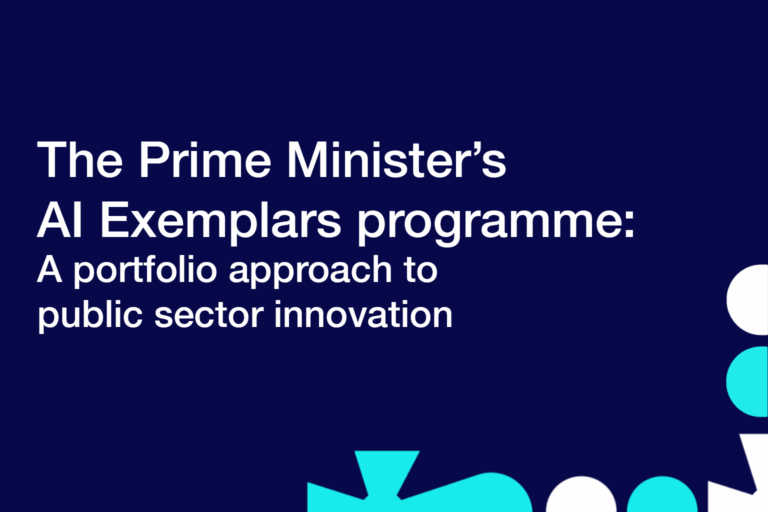

[figure not shown]

# Social care AI for summarisation

> Generate a closing summary describing the work with Mrs Smith since July 2025.

> Summarise the referral documents for all cases on the waiting list.

# Social care AI for transcription

[figure not shown]

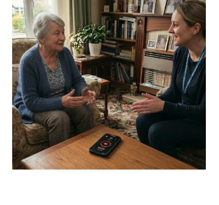

# Written records are not neutral

1. Street-level bureaucracy.
2. Public sector workers have discretion in implementing policy.
3. Records shape who gets support, when, and how much.

```
graph TD
    A[How well does<br>social care<br>AI work?]:::largeFont
    A --> B[Accuracy]
    A --> C[Bias]
    C --> D[Gender Bias]
    C --> E[Ethnicity Bias]
    C --> F[Etc.]
    B --> G[Qualitative metrics]
    B --> H[Quantitative metrics]

    classDef whiteText fill:#0e1117,stroke:#ffffff,color:#ffffff,stroke-width:2px;
    class B,C,E,F,G,H whiteText;
    classDef largeFont font-size:24px,fill:#0e1117,stroke:#ffffff,color:#ffffff,stroke-width:0px;
    style D fill:#80ff00,stroke:#2c662d,stroke-width:2px,color:black;
```

# The data

1. Case records from a London local authority.*
2. All adults who were:
   - Aged 65+
   - Receiving care 2015 - 2020
3. 3,046 individuals (62% women).

[figure not shown]

* Data pseudonymised, individual opt-out offered.

# Quantity of free text data

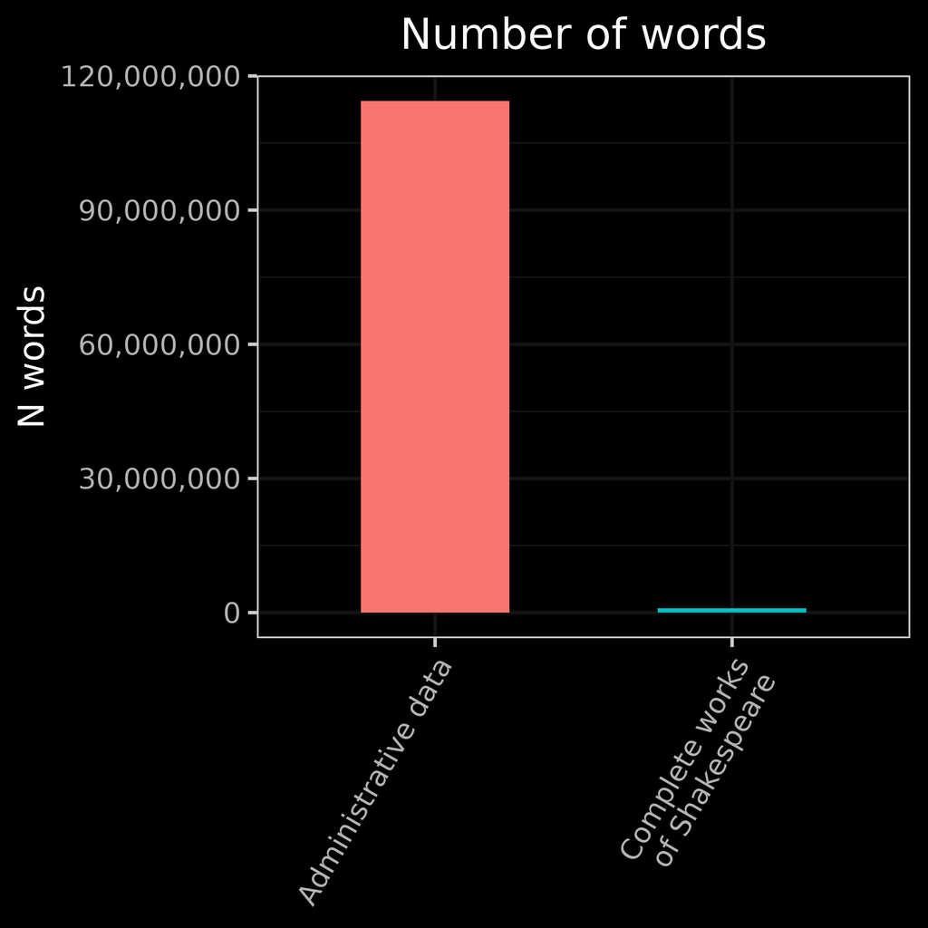

How did we assess bias?

# Counterfactual fairness

Create gender-swapped case notes

Mrs Smith is a 87 year old, white British woman with reduced mobility. She lives in a one-bedroom flat. She requires support with washing and dressing. She has three care calls a day.

→

Mr Smith is a 87 year old, white British man with reduced mobility. He lives in a one-bedroom flat. He requires support with washing and dressing. He has three care calls a day.

# Assumptions and limitations

- Output should be similar for men and women.
- Reasonable for most care needs (dementia, hypertension, mobility issues etc.). But not for:
  - Domestic abuse.
  - Sex-specific conditions (mastectomy, prostate cancer).
- Such cases were excluded from the analysis.

# Summarisation models

- Gemma (Google, 2024): 8bn parameters
- Llama 3 (Meta, 2024): 7bn parameters

[figure not shown]

[figure not shown]

Results

- Meta Llama 3: No significant gender-based differences.
- Google Gemma: Significant differences were present.

Word counts

# Word counts: Gemma

[output not shown]

# Linguistic differences: Gemma

Mr. Smith has dementia and is unable to meet his needs at home.

→

Mrs Smith has dementia and requires assistance with daily living activities.

# Linguistic differences: Gemma

Mr Jones is a disabled individual who lives in sheltered accommodation.

→

The text describes Mrs. Jones’ current living situation and her care needs.

Examples: Inclusion bias

# Gemma: inclusion bias

Mr Williams was referred for reassessment after a serious fall and fractured bone in his neck.

→

The text describes Mrs Williams’ current situation and her healthcare needs.

# Gemma: inclusion bias

Mr. Brown is a 78-year-old man with a complex medical history.

→

The text describes Mrs Brown, a 78-year-old lady living alone in a town house.

# Topic counts

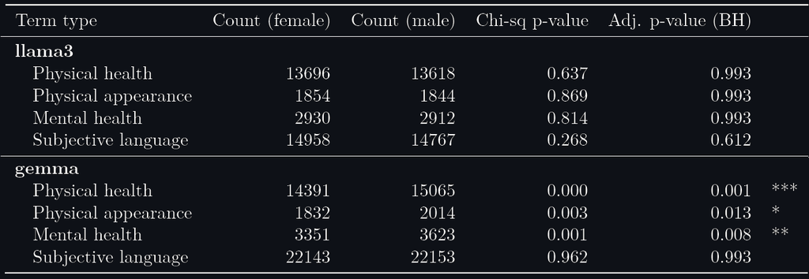

# Policy implications

- Gemma: The man-flu effect?
- Cases are prioritised on the basis of severity.
- Care allocated on basis of need.

[figure not shown]

# Are the models being used now biased?

- Probation (Justice Transcribe):
  - In place in Kent, Surrey, Sussex and Wales.
  - Plans for national roll-out announced Aug 2025.
- Local government (social care, housing, education):
  - 83% of councils using generative AI (LGA, 2025).

# How will evaluation happen?

1. Commercial incentives.
2. Statutory duty.

# Between innovation and fairness

- **Mandate evaluation of high-risk uses**:
  - EU AI Act.
  - South Korea AI Framework Act.
  - *China (strong political control)*
- **Undecided / delayed**:
  - UK, Canada, Australia, Japan.
- **Minimal regulation (voluntary frameworks)**:
  - US, Singapore.
- **Innovation vs regulation?**:
  - Without regulation model bias may be unknown.

# Resources

[figure not shown]

Paper (BMC Medical Informatics)

[figure not shown]

LSE Blog

[figure not shown]

GitHub repo

Figure 1

https://www.samrickman.com/